# Yukon Canadian-origin Chinook Salmon Inseason Bayesian Daily Projection

Aaron Lambert

2023-07-13

# July 12, 2023

Today’s forecast using the Bayesian inseason projection for Canadian-origin Chinook salmon returning to the Yukon River is found below. Given the preseason forecast and the observed Chinook salmon passage at PSS and Eagle Sonar up to July 12, 2023, there is a 5.5 % chance of meeting the lower range of the interim management escapement goal of 42,500-55,000 Canadian-origin Chinook salmon.

For this forecast, model version 4.0.2 is used (Normal curve fit to daily PSS passage and Eagle proportion est).

# Projected runsize quantiles

| Quantile | Run Size |
| --- | --- |
| 2.5% | 19331 |
| 10% | 22406 |
| 50% | 29840 |
| 90% | 39828 |
| 97.5% | 45800 |

# Cumulative PSS Chinook Passage (2005-2023)

Observed cumulative PSS passage from years 2005-2023. Note that the current year is plotted in black.

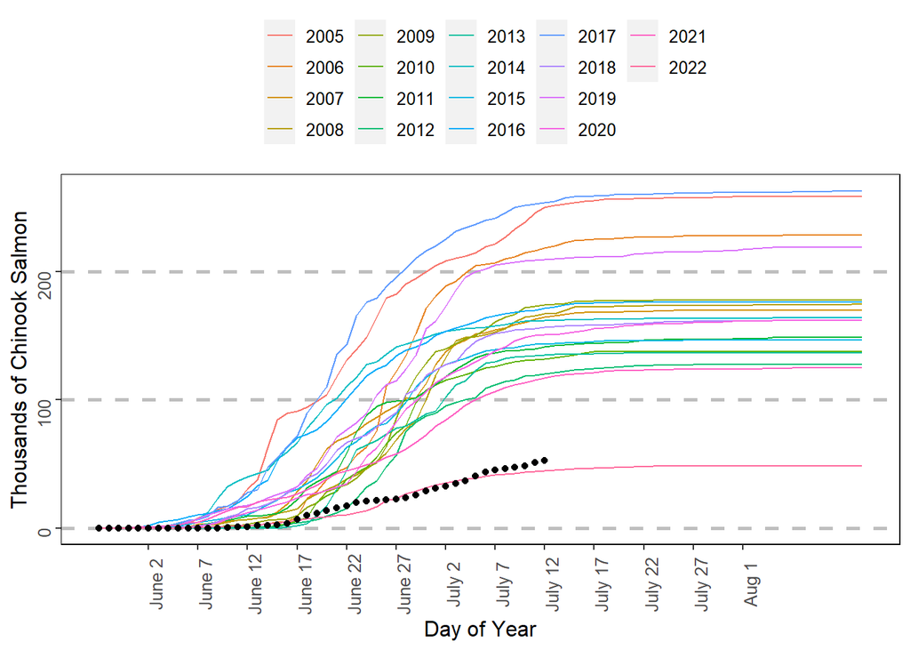

# Cumulative Eagle Sonar Chinook Passage (2005-2023)

Observed cumulative Eagle sonar passage from years 2005-2023. Note that the current year is plotted in black.

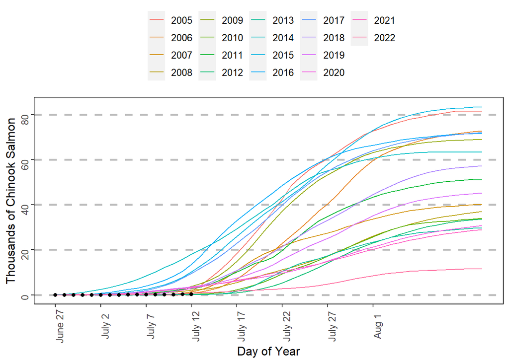

# Arrival Distribution

Curve fit to observed daily PSS Chinook salmon passage. This curve is used to project the number of Chinook salmon that will pass PSS at the end of the season to be used to project the end-of-season Canadian-origin Chinook salmon run size using a regression relationship. The average midpoint of the run from years 2005-2022 is plotted as a black dashed line.

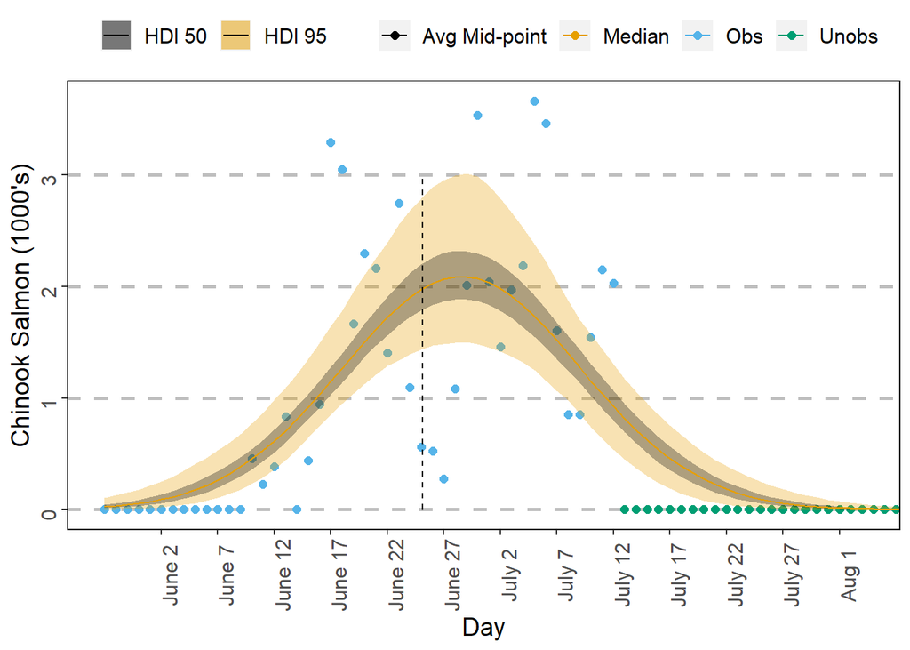

# PSS Regression Fit

Regression fit to the end-of-season cumulative PSS passage against historic observed Canadian-origin Chinook run size. Note that the current years prediction is based on summing up the observed passage up to the day of the forecast and adding the interpolated Chinook passage for the remainder of the season as predicted by fitting the normal distribution curve to observed passage.

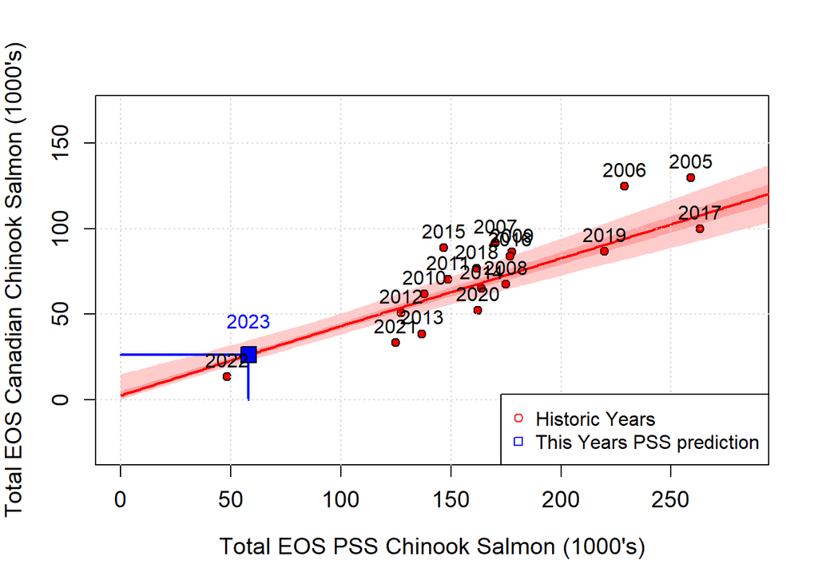

# Posterior density plots

Posterior density plots for EOS Canadian-origin Chinook salmon run size based on the preseason forecast point estimate and the empirical past performance, PSS sonar regression using predicted EOS PSS passage as the predictor variable, and Eagle Sonar passage based on the average observed proportion on the day the projection is made. Note that predictions based on Eagle Sonar are not used until Chinook salmon passage is observed at the border.

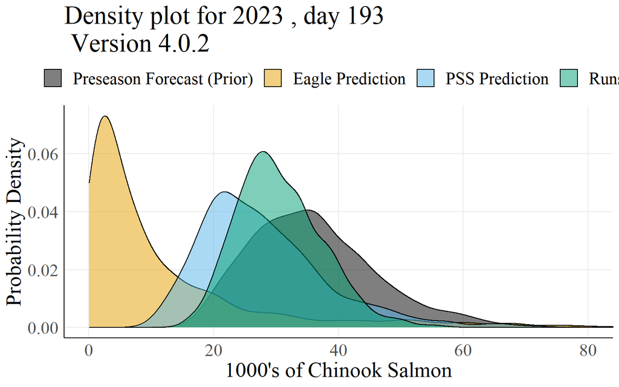

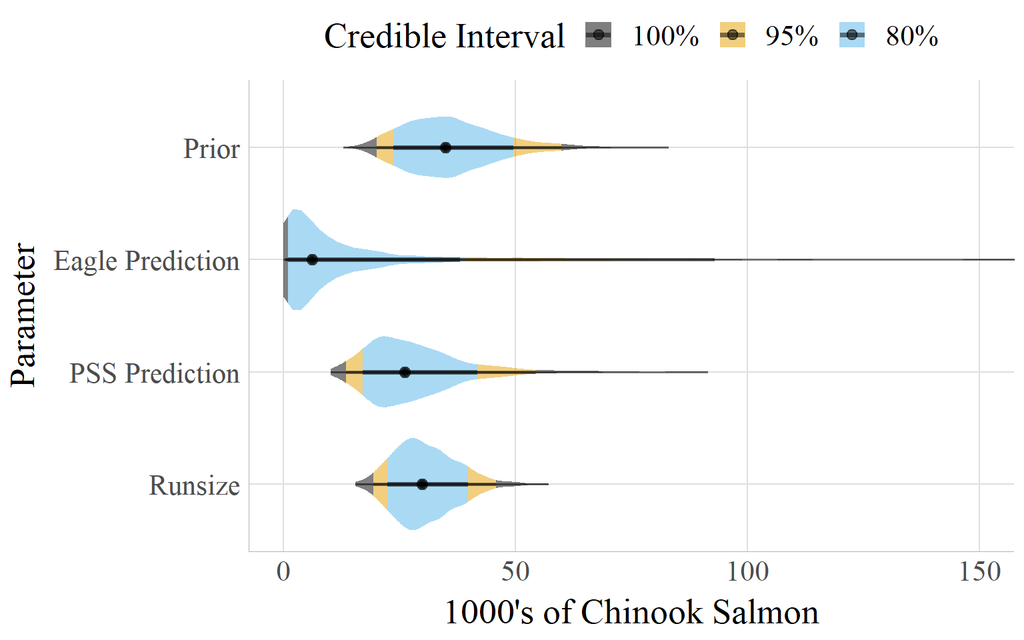